# Homework 03

## Question 1: Build an `explain-to-me` skill

Create a small skill named `explain-to-me` that helps you understand a homework question.

1. Design your `SKILL.md` file so that, when you explicitly ask your agent to use the skill to read a homework question, the agent communicates with you and explains what the question is asking.
2. Keep the skill file short. It should contain a few useful rules, instructions, and a clear statement of your intent. For example, you may ask the agent to explain the goal of the question, clarify what work is required, and point you to an appropriate section of the Week 3 lectures: [Ridge Regression: Stability Through Shrinkage](https://teazrq.github.io/stat432rpy/topics/ridge-regression/ridge-regression.html) or [From a Penalized Objective to a Fitted Ridge Model](https://teazrq.github.io/stat432rpy/topics/ridge-regression/optimization-and-cross-validation.html). The skill should help you understand the question without completing the solution for you.
3. Create the skill yourself or with the help of AI. Save it as `explain-to-me/SKILL.md`. Then ask your AI agent to install the skill using its normal skill-installation method. Test it by explicitly asking the agent to use `explain-to-me` to read and explain Question 2.
4. If the skill does not work well, or if it begins to disturb your usual workflow, ask your agent to remove the installed skill. You may revise and reinstall it if you wish.
5. In all cases, append the complete contents of your developed `explain-to-me/SKILL.md` file at the end of your Homework 3 submission under the heading **`explain-to-me` skill**.

## Question 2: Ridge regression with nearly collinear predictors

Let $n=100$. Generate mutually independent standard normal random variables

$$L_i, U_{i1}, U_{i2}, X_{i3}, X_{i4},
\qquad i=1,\ldots,n,$$

and define

$$X_{i1}=L_i+0.04U_{i1},
\qquad
X_{i2}=L_i+0.04U_{i2}.$$

Center and standardize each column of $\mathbf X$ to have mean zero and average squared value one, following the [lecture’s scaling convention](https://teazrq.github.io/stat432rpy/topics/ridge-regression/ridge-regression.html#put-every-covariate-on-a-common-scale).

Continue to use $\mathbf X\in\mathbb R^{n\times p}$ for the standardized matrix and keep it fixed throughout the question, where $p=4$ is the number of predictors. The unpenalized intercept gives $p+1=5$ total fitted coefficients. Let

$$\boldsymbol\beta
=
(1.5,1.5,1,0)^{\mathsf T},
\qquad
\boldsymbol\mu
=
\mathbf X\boldsymbol\beta.$$

Generate a training response and an independent test response at the same predictor values:

$$\begin{aligned}
\mathbf y
&=
\boldsymbol\mu+\boldsymbol\epsilon,\\
\mathbf y^*
&=
\boldsymbol\mu+\boldsymbol\epsilon^*,
\end{aligned}$$

where

$$\boldsymbol\epsilon,
\boldsymbol\epsilon^*
\overset{\mathrm{ind}}{\sim}
\mathcal N_n(\mathbf0,\mathbf I_n).$$

Center the training response as $\widetilde{\mathbf y}=\mathbf y-\bar y\mathbf1_n$. For each $\lambda\in\{0,0.02,0.2\}$, fit the slopes using the lecture’s ridge formula:

$$\widehat{\boldsymbol\beta}_\lambda
=
\left(\mathbf X^{\mathsf T}\mathbf X+n\lambda\mathbf I_p\right)^{-1}
\mathbf X^{\mathsf T}\widetilde{\mathbf y}.$$

The unpenalized intercept is $\widehat\beta_0=\bar y$; add this training mean back when predicting either response. The case $\lambda=0$ is ordinary least squares. Use seed `43231` before generating the design and responses. R and Python use different random-number generators, so their exact numerical results need not agree.

1. Generate $\mathbf X$ once. Report the correlation between its first two columns and its largest and smallest singular values. Use these quantities to explain why the estimator contrast $\widehat\beta_1-\widehat\beta_2$ should be much more variable than $\widehat\beta_1+\widehat\beta_2$.
2. Independently repeat the generation of $\mathbf y$ and $\mathbf y^*$, followed by all three fits, 200 times while keeping $\mathbf X$ fixed. Draw the training and test noise inside each repetition, then reuse that realized pair for all three values of $\lambda$. For each value of $\lambda$, report the empirical mean and standard deviation of

$$\widehat\beta_1,
\quad
\widehat\beta_2,
\quad
\widehat\beta_1+\widehat\beta_2,
\quad
\widehat\beta_1-\widehat\beta_2.$$

Also report the average training MSE and the average test MSE calculated from the independent test response, where

$$\operatorname{MSE}_{\mathrm{test}}
=
\frac{1}{n}
\left\lVert
\mathbf y^*
-
\widehat\beta_0\mathbf1_n
-
\mathbf X\widehat{\boldsymbol\beta}
\right\rVert_2^2.$$

3. Interpret the coefficient estimates and test MSE using bias and variance. Explain why ridge can substantially stabilize the individual coefficients without producing an equally large change in the fitted values.

### Answer

#### Part a

**Show the workflow**

```python
import numpy as np

np.random.seed(43231)
n = 100
L  = np.random.randn(n)
U1 = np.random.randn(n)
U2 = np.random.randn(n)
X3 = np.random.randn(n)
X4 = np.random.randn(n)

# build near-collinear pair
X1 = L + 0.04 * U1
X2 = L + 0.04 * U2

X = np.column_stack([X1, X2, X3, X4])

# center and standardize: mean 0, average squared value 1
Xc = X - X.mean(axis=0, keepdims=True)
scale = np.sqrt((Xc**2).mean(axis=0))
X = Xc / scale   # this is the standardized design matrix used throughout

# correlation between first two columns
corr12 = np.corrcoef(X[:, 0], X[:, 1])[0, 1]

# singular values via SVD
U, S, Vt = np.linalg.svd(X, full_matrices=False)

print("corr(X1, X2) =", corr12)
print("singular values:", S)
print("largest singular value:", S.max())
print("smallest singular value:", S.min())
```

```
corr(X1, X2) = 0.998268878796455
singular values: [14.15123473 10.1830787   9.7916542   0.41348737]
largest singular value: 14.15123472889276
smallest singular value: 0.41348736987744283
```

corr(X₁, X₂) ≈ 0.9983, and the singular values are approximately [14.151, 10.183, 9.792, 0.413], so $d_{\max}\approx14.151$ and $d_{\min}\approx0.413$.

Because $X_1$ and $X_2$ are both built from the same $L_i$ plus a tiny independent perturbation, they are almost identical ($r\approx0.998$), which makes $\mathbf X$ nearly rank-deficient. This shows up in the singular values: three are moderate-to-large ($\approx14.15,\,10.18,\,9.79$), but the smallest is tiny ($d_{\min}\approx0.41$) — that small value is the signature of the near-collinearity between $X_1$ and $X_2$.

Since $\text{Var}(\widehat{\boldsymbol\beta}) = \sigma^2(\mathbf X^\top\mathbf X)^{-1} = \sigma^2\mathbf V\mathbf D^{-2}\mathbf V^\top$, the variance of any contrast $\mathbf c^\top\widehat{\boldsymbol\beta}$ depends on how well $\mathbf c$ aligns with each singular direction, weighted by $1/d_j^2$. The contrast $\hat\beta_1-\hat\beta_2$ essentially points along the near-null direction of $\mathbf X$ (since $X_1-X_2\approx0.04(U_1-U_2)$ is almost pure noise, carrying almost no signal), so its variance is inflated by roughly $1/d_{\min}^2$. The contrast $\hat\beta_1+\hat\beta_2$, on the other hand, points along the direction of $2L_i$, which aligns with one of the large singular values, so its variance only scales like $1/d_{\max}^2$.

The ratio of these two variance-inflation factors is on the order of $(d_{\max}/d_{\min})^2 \approx (14.151/0.413)^2\approx 1171$. So $\hat\beta_1-\hat\beta_2$ should be dramatically more variable than $\hat\beta_1+\hat\beta_2$: the data strongly pin down the total effect of the shared factor $L_i$ (the sum), but there’s almost no information in $\mathbf X$ to distinguish how much of that effect belongs to $X_1$ versus $X_2$ individually, so the split between $\hat\beta_1$ and $\hat\beta_2$ (their difference) is highly sensitive to noise in $\mathbf y$.

#### Part b

**Show the workflow**

```python
np.random.seed(43231)
n = 100

# --- generate X once (same as part a) ---
L  = np.random.randn(n)
U1 = np.random.randn(n)
U2 = np.random.randn(n)
X3 = np.random.randn(n)
X4 = np.random.randn(n)

X1 = L + 0.04 * U1
X2 = L + 0.04 * U2

X = np.column_stack([X1, X2, X3, X4])
Xc = X - X.mean(axis=0, keepdims=True)
scale = np.sqrt((Xc**2).mean(axis=0))
X = Xc / scale
n, p = X.shape

beta_true = np.array([1.5, 1.5, 1.0, 0.0])
mu = X @ beta_true

lambdas = [0, 0.02, 0.2]
nrep = 200

results = {lam: {"b1": [], "b2": [], "sum": [], "diff": [],
                  "trainMSE": [], "testMSE": []} for lam in lambdas}

for rep in range(nrep):
    eps      = np.random.randn(n)
    eps_star = np.random.randn(n)
    y      = mu + eps
    ystar  = mu + eps_star

    ybar   = y.mean()
    ytilde = y - ybar

    for lam in lambdas:
        A = X.T @ X + n * lam * np.eye(p)
        b = np.linalg.solve(A, X.T @ ytilde)

        beta0  = ybar
        fitted = beta0 + X @ b          # same X used for train and test

        train_mse = np.mean((y - fitted) ** 2)
        test_mse  = np.mean((ystar - fitted) ** 2)

        results[lam]["b1"].append(b[0])
        results[lam]["b2"].append(b[1])
        results[lam]["sum"].append(b[0] + b[1])
        results[lam]["diff"].append(b[0] - b[1])
        results[lam]["trainMSE"].append(train_mse)
        results[lam]["testMSE"].append(test_mse)

for lam in lambdas:
    print(f"\nlambda = {lam}")
    for key in ["b1", "b2", "sum", "diff"]:
        arr = np.array(results[lam][key])
        print(f"  {key:5s}: mean = {arr.mean():7.4f},  sd = {arr.std(ddof=1):7.4f}")
    print(f"  train MSE mean: {np.mean(results[lam]['trainMSE']):.4f}")
    print(f"  test  MSE mean: {np.mean(results[lam]['testMSE']):.4f}")
```

```
lambda = 0
  b1   : mean =  1.4482,  sd =  1.6289
  b2   : mean =  1.5505,  sd =  1.6295
  sum  : mean =  2.9987,  sd =  0.0919
  diff : mean = -0.1023,  sd =  3.2570
  train MSE mean: 0.9332
  test  MSE mean: 1.0475

lambda = 0.02
  b1   : mean =  1.4827,  sd =  0.1357
  b2   : mean =  1.4871,  sd =  0.1364
  sum  : mean =  2.9698,  sd =  0.0910
  diff : mean = -0.0044,  sd =  0.2565
  train MSE mean: 0.9421
  test  MSE mean: 1.0402

lambda = 0.2
  b1   : mean =  1.3674,  sd =  0.0438
  b2   : mean =  1.3649,  sd =  0.0441
  sum  : mean =  2.7323,  sd =  0.0835
  diff : mean =  0.0025,  sd =  0.0276
  train MSE mean: 1.0420
  test  MSE mean: 1.1328
```

| $\lambda$ | $\hat\beta_1$ mean (sd) | $\hat\beta_2$ mean (sd) | $\hat\beta_1+\hat\beta_2$ mean (sd) | $\hat\beta_1-\hat\beta_2$ mean (sd) | Train MSE | Test MSE |
| --- | --- | --- | --- | --- | --- | --- |
| 0 (OLS) | 1.448 (1.629) | 1.551 (1.630) | 2.999 (0.092) | −0.102 (3.257) | 0.933 | 1.048 |
| 0.02 | 1.483 (0.136) | 1.487 (0.136) | 2.970 (0.091) | −0.004 (0.257) | 0.942 | 1.040 |
| 0.2 | 1.367 (0.044) | 1.365 (0.044) | 2.732 (0.084) | 0.003 (0.028) | 1.042 | 1.133 |

The simulation confirms the intuition from part (a). At $\lambda=0$ (OLS), both $\hat\beta_1$ and $\hat\beta_2$ are essentially unbiased (means near 1.5) but extremely noisy, with standard deviations around 1.6 — a direct consequence of the tiny singular value associated with the near-collinear pair. The sum $\hat\beta_1+\hat\beta_2$ is already tightly concentrated (sd $\approx0.09$) even without penalty, since it lives in the well-estimated large-singular-value direction, while the difference $\hat\beta_1-\hat\beta_2$ is wildly unstable (sd $\approx3.26$), dwarfing the true value of zero, since it lives in the near-null direction.

As $\lambda$ increases from 0 to 0.02 to 0.2, the individual coefficients and especially the difference contract sharply toward more stable values: the sd of $\hat\beta_1-\hat\beta_2$ falls from 3.26 to 0.26 to 0.03, while the sd of the sum barely moves (0.092 → 0.091 → 0.084). This asymmetric shrinkage is exactly what ridge regression targets — it suppresses variance most in directions with small singular values.

Test MSE is minimized at the small penalty $\lambda=0.02$ (1.040), slightly beating OLS (1.048), reflecting the classic bias–variance tradeoff: a small amount of shrinkage removes a large amount of variance in the unstable difference direction at almost no bias cost. At $\lambda=0.2$ the penalty is too strong — it begins biasing the well-estimated sum direction as well, and test MSE rises to 1.133. Training MSE increases monotonically with $\lambda$ (0.933 → 0.942 → 1.042), as expected, since ridge always fits the training data somewhat worse by construction, but this does not track test performance in the same way.

#### Part c

**Individual coefficients.** At $\lambda=0$ (OLS), $\hat\beta_1$ and $\hat\beta_2$ are essentially unbiased — their means (1.448, 1.551) are close to the true values (1.5, 1.5) — but their variance is enormous (sd $\approx1.6$ each), because the near-collinearity between $X_1$ and $X_2$ leaves the data almost unable to tell OLS how to split credit for the shared signal between the two predictors. As $\lambda$ increases to 0.02 and then 0.2, the standard deviations collapse (to about 0.14 and then 0.04), but at the cost of growing bias: the means drift downward (to about 1.48, then 1.37) as ridge shrinks coefficients toward zero. This is the standard ridge bias–variance tradeoff, but it plays out very unevenly across directions.

**Sum vs. difference.** $\hat\beta_1+\hat\beta_2$ is already low-variance and nearly unbiased even at $\lambda=0$ (sd $\approx0.09$), because it lies along the well-determined, large-singular-value direction of $\mathbf X$ (essentially the shared factor $L_i$); ridge shrinks its mean only modestly as $\lambda$ grows and barely touches its variance. In sharp contrast, $\hat\beta_1-\hat\beta_2$ is wildly unstable at $\lambda=0$ (sd $\approx3.26$, far exceeding the entire signal) because it is driven almost entirely by noise in the near-null singular direction. Even a tiny penalty ($\lambda=0.02$) collapses its sd to 0.26, and $\lambda=0.2$ nearly eliminates the variability (sd $\approx0.03$), correctly reflecting that the true contrast $\beta_1-\beta_2=0$.

**Test MSE and the bias–variance tradeoff.** Test MSE is minimized at the small penalty $\lambda=0.02$ (1.040), just below OLS’s 1.048, and worse at $\lambda=0.2$ (1.133). This is a textbook bias–variance picture: a small ridge penalty removes a huge amount of variance in the unstable near-null direction at essentially no bias cost, improving prediction slightly over OLS. Push the penalty too far (0.2), however, and it starts biasing the well-estimated signal-carrying direction as well — now the added bias outweighs the (already small) further variance reduction, and test MSE rises. Training MSE, by contrast, increases monotonically with $\lambda$ (0.933 → 0.942 → 1.042), since ridge always fits the training data somewhat worse by construction — but training MSE is not a reliable guide to test performance, which is exactly the point of this exercise.

**Why ridge stabilizes coefficients without changing fitted values as much.** In the SVD basis $\mathbf X = \mathbf U\mathbf D\mathbf V^\top$, ridge regression shrinks the coefficient along each principal direction $j$ by the factor

$$\frac{d_j^2}{d_j^2 + n\lambda},$$

and the fitted values $\mathbf X\widehat{\boldsymbol\beta}$ depend on these shrunken coefficients weighted by $d_j$ in a way that keeps strong directions almost untouched. For a direction with a *large* singular value (like the shared $X_1+X_2$ signal direction, which carries almost all of the true predictive information), $d_j^2 \gg n\lambda$ for the small $\lambda$’s used here, so the shrinkage factor stays close to 1 — that part of the fit, and hence the fitted values and test predictions, changes very little. But for the direction with a *tiny* singular value (the $X_1-X_2$ contrast, which is almost pure noise with essentially no real signal), the same $n\lambda$ term dominates $d_j^2$, so the shrinkage factor collapses toward 0 quickly.

Because the individual coefficients $\hat\beta_1$ and $\hat\beta_2$ are linear combinations of *both* the strong (sum) and weak (difference) directions, suppressing the noisy weak direction alone produces a large, visible stabilization in $\hat\beta_1$ and $\hat\beta_2$ individually. But since that weak direction carried almost no real signal to begin with, removing its noisy contribution barely changes the fitted values or predictions — the meaningful part of the fit (driven by the strong, shared-signal direction) survives almost untouched. This is why ridge can dramatically stabilize individual, poorly-identified coefficients in the presence of collinearity while leaving overall predictive performance nearly unchanged (or, as seen here with $\lambda=0.02$, even slightly improved).

## Question 3: What does ridge regression shrink?

Let $\mathbf X\in\mathbb R^{n\times p}$ be a centered predictor matrix, and let $\widetilde{\mathbf y}\in\mathbb R^n$ be the centered response. Use the supplied predictor scales for this algebraic question; the columns need not have unit variance. Here $p$ counts predictors, $\boldsymbol\beta\in\mathbb R^p$ contains their slopes, and $p+1$ counts all fitted coefficients, including the separately fitted, unpenalized intercept. Ridge regression minimizes

$$L_\lambda(\boldsymbol\beta)
=
\frac{1}{2n}
\left\lVert
\widetilde{\mathbf y}-\mathbf X\boldsymbol\beta
\right\rVert_2^2
+
\frac{\lambda}{2}
\lVert\boldsymbol\beta\rVert_2^2.$$

1. Derive the ridge normal equation

$$\left(
\mathbf X^{\mathsf T}\mathbf X
+n\lambda\mathbf I_p
\right)
\widehat{\boldsymbol\beta}_\lambda
=
\mathbf X^{\mathsf T}\widetilde{\mathbf y}.$$

Explain why it has a unique solution whenever $\lambda>0$, even if $\mathbf X$ is rank deficient or $p>n$.

2. Let

$$\mathbf X
=
\mathbf U_r\mathbf D_r\mathbf V_r^{\mathsf T}$$

be a compact singular value decomposition, where $r=\operatorname{rank}(\mathbf X)$, $\mathbf U_r\in\mathbb R^{n\times r}$, $\mathbf D_r\in\mathbb R^{r\times r}$, and $\mathbf V_r\in\mathbb R^{p\times r}$. Show that ridge multiplies the fitted response component in the $j$th left singular-vector direction, for $j=1,\ldots,r$, by

$$\rho_j(\lambda)
=
\frac{d_j^2}{d_j^2+n\lambda}.$$

Suppose $n=100$, $\lambda=0.01$, and the nonzero singular values are

$$d_1=10,
\qquad
d_2=2,
\qquad
d_3=0.2.$$

Calculate the three shrinkage factors and the total effective degrees of freedom, including the unpenalized intercept:

$$\operatorname{df}_{\mathrm{eff}}(\lambda)
=
1+\sum_{j=1}^3\rho_j(\lambda).$$

3. Which direction receives the strongest shrinkage? Explain why shrinking this direction can reduce prediction variance. Under what circumstance could the same shrinkage produce substantial prediction bias?

### Answer

#### Part a

**Derivation.** The ridge objective is
$$L_\lambda(\boldsymbol\beta) = \frac{1}{2n}\lVert\widetilde{\mathbf y}-\mathbf X\boldsymbol\beta\rVert_2^2 + \frac{\lambda}{2}\lVert\boldsymbol\beta\rVert_2^2 .$$
Differentiate with respect to $\boldsymbol\beta$ and set the gradient to zero:
$$\nabla_{\boldsymbol\beta} L_\lambda(\boldsymbol\beta) = -\frac{1}{n}\mathbf X^\top(\widetilde{\mathbf y}-\mathbf X\boldsymbol\beta) + \lambda\boldsymbol\beta = \mathbf 0 .$$
Multiplying through by $n$:
$$-\mathbf X^\top\widetilde{\mathbf y} + \mathbf X^\top\mathbf X\boldsymbol\beta + n\lambda\boldsymbol\beta = \mathbf 0
\quad\Longrightarrow\quad
\left(\mathbf X^\top\mathbf X + n\lambda\mathbf I_p\right)\widehat{\boldsymbol\beta}_\lambda = \mathbf X^\top\widetilde{\mathbf y}.$$
Since $L_\lambda$ is a quadratic function with Hessian $\frac{1}{n}\mathbf X^\top\mathbf X + \lambda\mathbf I_p \succeq \lambda \mathbf I_p \succ 0$ (for $\lambda>0$), this is not just a stationary point but the unique global minimizer.

**Why the solution is unique for any $\lambda>0$.** $\mathbf X^\top\mathbf X$ is symmetric positive semi-definite, so all its eigenvalues satisfy $\mu_k \geq 0$ — this holds regardless of whether $\mathbf X$ is rank-deficient or $p>n$ (in which case $\mathbf X^\top\mathbf X$ is necessarily singular, with some $\mu_k=0$). Adding $n\lambda\mathbf I_p$ shifts every eigenvalue by $n\lambda>0$, so the eigenvalues of $\mathbf X^\top\mathbf X+n\lambda\mathbf I_p$ are $\mu_k+n\lambda \geq n\lambda>0$ for all $k$. A symmetric matrix with strictly positive eigenvalues is positive definite, hence invertible. Therefore $\widehat{\boldsymbol\beta}_\lambda = (\mathbf X^\top\mathbf X+n\lambda\mathbf I_p)^{-1}\mathbf X^\top\widetilde{\mathbf y}$ exists and is unique — even when $\mathbf X^\top\mathbf X$ itself is singular (rank-deficient design, or $p>n$), the ridge penalty regularizes exactly the directions where $\mathbf X^\top\mathbf X$ has zero (or near-zero) eigenvalues.

#### Part b

**Setup.** Let $\mathbf X = \mathbf U_r\mathbf D_r\mathbf V_r^\top$ be the compact SVD, with $\mathbf U_r^\top\mathbf U_r = \mathbf I_r$, $\mathbf V_r^\top\mathbf V_r=\mathbf I_r$, and $\mathbf D_r=\text{diag}(d_1,\dots,d_r)$, $d_j>0$.

**Deriving $\widehat{\boldsymbol\beta}_\lambda$.** Extend $\mathbf V_r$ to a full orthogonal basis $\mathbf V=[\mathbf V_r\ \ \mathbf V_r^{\perp}]\in\mathbb R^{p\times p}$. Since $\mathbf X^\top\mathbf X = \mathbf V_r\mathbf D_r^2\mathbf V_r^\top$ and $\mathbf I_p = \mathbf V_r\mathbf V_r^\top + \mathbf V_r^{\perp}\mathbf V_r^{\perp\top}$,
$$\mathbf X^\top\mathbf X + n\lambda\mathbf I_p = \mathbf V_r(\mathbf D_r^2+n\lambda\mathbf I_r)\mathbf V_r^\top + n\lambda\,\mathbf V_r^{\perp}\mathbf V_r^{\perp\top}.$$
Because $\mathbf V_r$ and $\mathbf V_r^\perp$ are orthogonal blocks, this inverts blockwise:
$$(\mathbf X^\top\mathbf X+n\lambda\mathbf I_p)^{-1} = \mathbf V_r(\mathbf D_r^2+n\lambda\mathbf I_r)^{-1}\mathbf V_r^\top + \frac{1}{n\lambda}\mathbf V_r^{\perp}\mathbf V_r^{\perp\top}.$$
Multiplying by $\mathbf X^\top\widetilde{\mathbf y} = \mathbf V_r\mathbf D_r\mathbf U_r^\top\widetilde{\mathbf y}$, the second term vanishes (since $\mathbf V_r^{\perp\top}\mathbf V_r=\mathbf 0$), leaving
$$\widehat{\boldsymbol\beta}_\lambda = \mathbf V_r(\mathbf D_r^2+n\lambda\mathbf I_r)^{-1}\mathbf D_r\,\mathbf U_r^\top\widetilde{\mathbf y}.$$

**Fitted values.**
$$\mathbf X\widehat{\boldsymbol\beta}_\lambda = \mathbf U_r\mathbf D_r\mathbf V_r^\top\widehat{\boldsymbol\beta}_\lambda = \mathbf U_r\,\mathbf D_r(\mathbf D_r^2+n\lambda\mathbf I_r)^{-1}\mathbf D_r\,\mathbf U_r^\top\widetilde{\mathbf y} = \mathbf U_r\,\text{diag}\!\left(\frac{d_j^2}{d_j^2+n\lambda}\right)\mathbf U_r^\top\widetilde{\mathbf y}.$$
Writing $\widetilde{\mathbf y} = \sum_{j=1}^r (\mathbf u_j^\top\widetilde{\mathbf y})\mathbf u_j + (\text{component orthogonal to }\mathbf U_r)$, the fitted value is
$$\mathbf X\widehat{\boldsymbol\beta}_\lambda = \sum_{j=1}^r \rho_j(\lambda)\,(\mathbf u_j^\top\widetilde{\mathbf y})\,\mathbf u_j, \qquad \rho_j(\lambda) = \frac{d_j^2}{d_j^2+n\lambda}.$$
So the component of $\widetilde{\mathbf y}$ along each left singular direction $\mathbf u_j$ is scaled by exactly $\rho_j(\lambda) \in (0,1)$ — this **is** the shrinkage factor. (For comparison, OLS, $\lambda=0$, gives $\rho_j=1$ for every $j$ with $d_j>0$: no shrinkage.)

**Numerical example.** With $n=100$, $\lambda=0.01 \Rightarrow n\lambda=1$:

**Show the workflow**

```python
n = 100
lam = 0.01
n_lam = n * lam  # = 1

d = [10, 2, 0.2]
rho = [d_j**2 / (d_j**2 + n_lam) for d_j in d]

for j, (dj, rj) in enumerate(zip(d, rho), start=1):
    print(f"d_{j} = {dj:>5}: rho_{j}(lambda) = {rj:.4f}")

df_eff = 1 + sum(rho)
print(f"\nEffective df (including intercept) = {df_eff:.4f}")
```

```
d_1 =    10: rho_1(lambda) = 0.9901
d_2 =     2: rho_2(lambda) = 0.8000
d_3 =   0.2: rho_3(lambda) = 0.0385

Effective df (including intercept) = 2.8286
```

$$\rho_1(\lambda)=\frac{100}{101}\approx 0.9901,\qquad
\rho_2(\lambda)=\frac{4}{5}=0.8000,\qquad
\rho_3(\lambda)=\frac{0.04}{1.04}\approx 0.0385,$$
$$\operatorname{df}_{\mathrm{eff}}(\lambda) = 1+0.9901+0.8000+0.0385 \approx 2.8286.$$

#### Part c

**Strongest shrinkage.** The third direction ($d_3=0.2$) receives by far the strongest shrinkage, $\rho_3\approx0.038$ — its contribution to the fitted values is reduced to under 4% of what OLS would use. In general $\rho_j(\lambda)$ is increasing in $d_j$: large singular values (strong, well-determined directions of $\mathbf X$) are barely shrunk, while small singular values (weak, poorly-determined directions) are shrunk almost to zero.

**Why shrinking this direction reduces prediction variance.** For OLS, the variance of the fitted-value component along $\mathbf u_j$ is $\sigma^2$ times a weight that grows like $1/d_j^2$ once you propagate back through $\widehat{\boldsymbol\beta}$ — equivalently, the corresponding coefficient-space direction $\mathbf v_j$ has $\text{Var}(\mathbf v_j^\top\widehat{\boldsymbol\beta}_{\text{OLS}}) = \sigma^2/d_j^2$, which is huge when $d_j$ is small. Ridge’s shrinkage factor $\rho_j(\lambda) = d_j^2/(d_j^2+n\lambda)$ multiplies that variance by $\rho_j(\lambda)^2$, so the ridge-estimated variance in that direction is $\sigma^2 d_j^2/(d_j^2+n\lambda)^2$, which is dramatically smaller than the OLS variance whenever $n\lambda \gg d_j^2$ (as with $d_3=0.2$ here). Because this direction contributes little signal to $\mathbf X$ to begin with (small $d_j$ means the predictors vary little along $\mathbf v_j$), most of what OLS is fitting there is noise — so suppressing it removes mostly variance, not information.

**When this same shrinkage could produce substantial bias.** If the *true* coefficient vector $\boldsymbol\beta^*$ has a large projection onto $\mathbf v_3$ — i.e., the true signal genuinely depends strongly on the weak (small-$d_3$) direction of $\mathbf X$ — then aggressively shrinking that direction discards real signal, not just noise. In that case $\mathbb E[\mathbf v_3^\top\widehat{\boldsymbol\beta}_\lambda] = \rho_3(\lambda)\,\mathbf v_3^\top\boldsymbol\beta^*$ is pulled far from the true value $\mathbf v_3^\top\boldsymbol\beta^*$, producing substantial bias in both the coefficients and the fitted values along that direction. This is the core tension: ridge shrinkage helps most when weak singular directions carry mostly noise (as engineered in Question 2 by nearly collinear predictors), but hurts when weak directions happen to carry real signal — the practitioner cannot tell which is the case from $d_j$ alone, which is why $\lambda$ must be tuned (e.g., by cross-validation) to balance this bias–variance tradeoff rather than fixed a priori.

## Question 4: Ridge regression and optimization

Let $\mathbf X\in\mathbb R^{n\times p}$ be a centered predictor matrix with $p=2$. Its columns need not have unit variance in this question. The intercept is fitted separately and is not penalized. Suppose the two eigenvalues of

$$\mathbf A_0
=
\frac{1}{n}\mathbf X^{\mathsf T}\mathbf X$$

are $9$ and $0.01$. Ridge regression with $\lambda=0.09$ has curvature matrix

$$\mathbf A_\lambda
=
\frac{1}{n}\mathbf X^{\mathsf T}\mathbf X
+
\lambda\mathbf I_p.$$

1. Calculate the condition numbers of $\mathbf A_0$ and $\mathbf A_\lambda$. Explain what the change says about the geometry of the ridge objective.
2. Gradient descent uses

$$\boldsymbol\beta^{(k+1)}
=
\boldsymbol\beta^{(k)}
-
\eta\nabla L_\lambda\!\left(\boldsymbol\beta^{(k)}\right).$$

Let $\widehat{\boldsymbol\beta}_\lambda$ be the ridge minimizer and define the optimization error

$$\mathbf e^{(k)}
=
\boldsymbol\beta^{(k)}
-
\widehat{\boldsymbol\beta}_\lambda.$$

Show that the component of $\mathbf e^{(k)}$ in an eigendirection with unpenalized eigenvalue $a$ is multiplied at each step by

$$1-\eta(a+\lambda).$$

Let $M=9.09$, the largest eigenvalue of $\mathbf A_\lambda$. Find the interval of step sizes that contracts every eigendirection. Then compare these two choices:

- For $\eta=1/M$, calculate the two contraction factors and explain which direction converges faster.
- For $\eta=2.1/M$, determine whether the method converges. Assume the initial error has a nonzero component in the eigendirection corresponding to $M$.
3. Increasing $\lambda$ generally improves the condition number. Explain why choosing $\lambda$ to make gradient descent converge as quickly as possible is not a valid statistical tuning rule.

### Answer

#### Part a

The condition number of a symmetric positive-definite matrix is the ratio of its largest to smallest eigenvalue.

**Show the workflow**

```python
eig_A0 = [9, 0.01]
lam = 0.09
eig_Alam = [e + lam for e in eig_A0]

cond_A0 = max(eig_A0) / min(eig_A0)
cond_Alam = max(eig_Alam) / min(eig_Alam)

print("Eigenvalues of A0:", eig_A0, " -> condition number:", cond_A0)
print("Eigenvalues of A_lambda:", eig_Alam, " -> condition number:", cond_Alam)
```

```
Eigenvalues of A0: [9, 0.01]  -> condition number: 900.0
Eigenvalues of A_lambda: [9.09, 0.09999999999999999]  -> condition number: 90.9
```

$$\kappa(\mathbf A_0) = \frac{9}{0.01} = 900, \qquad
\kappa(\mathbf A_\lambda) = \frac{9.09}{0.10} = 90.9.$$

**Interpretation.** Since $\mathbf A_\lambda = \mathbf A_0 + \lambda\mathbf I_p$ shares $\mathbf A_0$’s eigenvectors and simply shifts every eigenvalue up by $\lambda$, the ridge penalty raises the *smallest* eigenvalue proportionally far more than the largest one (in relative terms: $0.01\to0.10$ is a 10-fold increase, while $9\to9.09$ is barely a 1% increase). This flattens the eigenvalue spectrum and shrinks the condition number by a factor of 10, from 900 down to 90.9. Geometrically, the level sets of $L_0$ (unpenalized least squares) are extremely elongated ellipses — nearly flat in the direction of the small eigenvalue — while the level sets of $L_\lambda$ are much closer to circular. A more circular (well-conditioned) objective is much friendlier to gradient-based optimization: gradient descent zig-zags badly on elongated, ill-conditioned bowls, but converges quickly and directly on well-conditioned ones.

#### Part b

**Deriving the recursion.** The ridge loss is $L_\lambda(\boldsymbol\beta) = \frac{1}{2n}\lVert\widetilde{\mathbf y}-\mathbf X\boldsymbol\beta\rVert_2^2+\frac{\lambda}{2}\lVert\boldsymbol\beta\rVert_2^2$, with gradient
$$\nabla L_\lambda(\boldsymbol\beta) = \frac{1}{n}\mathbf X^\top\mathbf X\boldsymbol\beta - \frac{1}{n}\mathbf X^\top\widetilde{\mathbf y} + \lambda\boldsymbol\beta = \mathbf A_\lambda\boldsymbol\beta - \frac{1}{n}\mathbf X^\top\widetilde{\mathbf y}.$$
At the minimizer, $\nabla L_\lambda(\widehat{\boldsymbol\beta}_\lambda)=\mathbf 0$, so $\frac{1}{n}\mathbf X^\top\widetilde{\mathbf y} = \mathbf A_\lambda\widehat{\boldsymbol\beta}_\lambda$. Substituting back,
$$\nabla L_\lambda(\boldsymbol\beta) = \mathbf A_\lambda\boldsymbol\beta - \mathbf A_\lambda\widehat{\boldsymbol\beta}_\lambda = \mathbf A_\lambda(\boldsymbol\beta-\widehat{\boldsymbol\beta}_\lambda).$$
So the gradient descent update becomes
$$\boldsymbol\beta^{(k+1)} - \widehat{\boldsymbol\beta}_\lambda = \left(\boldsymbol\beta^{(k)}-\widehat{\boldsymbol\beta}_\lambda\right) - \eta\,\mathbf A_\lambda\left(\boldsymbol\beta^{(k)}-\widehat{\boldsymbol\beta}_\lambda\right)
\quad\Longrightarrow\quad
\mathbf e^{(k+1)} = \left(\mathbf I_p - \eta\mathbf A_\lambda\right)\mathbf e^{(k)}.$$
Since $\mathbf A_\lambda = \mathbf A_0+\lambda\mathbf I_p$ is diagonalized by the same eigenvectors as $\mathbf A_0$, and an eigendirection with unpenalized eigenvalue $a$ (eigenvalue of $\mathbf A_0$) has eigenvalue $a+\lambda$ under $\mathbf A_\lambda$, the corresponding eigenvalue of $\mathbf I_p-\eta\mathbf A_\lambda$ is $1-\eta(a+\lambda)$. Hence the component of $\mathbf e^{(k)}$ along that eigendirection is multiplied by exactly
$$1-\eta(a+\lambda)$$
at every iteration, as required.

**Interval of step sizes that contracts both directions.** The two eigenvalues of $\mathbf A_\lambda$ are $M=9.09$ and $m=0.10$. Contraction in a given direction requires $|1-\eta\mu|<1$, i.e. $0<\eta<2/\mu$. For *both* directions to contract simultaneously, $\eta$ must satisfy the tighter (larger-eigenvalue) constraint:
$$0 < \eta < \frac{2}{M} = \frac{2}{9.09} \approx 0.220.$$

**Show the workflow**

```python
M = 9.09
m = 0.10

eta_bound = 2 / M
print(f"Contracts-everywhere interval: 0 < eta < {eta_bound:.4f}")

# eta = 1/M
eta1 = 1 / M
factor_M_1 = 1 - eta1 * M
factor_m_1 = 1 - eta1 * m
print(f"\neta = 1/M = {eta1:.4f}")
print(f"  contraction factor (M direction) = {factor_M_1:.4f}")
print(f"  contraction factor (m direction) = {factor_m_1:.4f}")

# eta = 2.1/M
eta2 = 2.1 / M
factor_M_2 = 1 - eta2 * M
factor_m_2 = 1 - eta2 * m
print(f"\neta = 2.1/M = {eta2:.4f}")
print(f"  factor (M direction) = {factor_M_2:.4f}  (|.| = {abs(factor_M_2):.4f})")
print(f"  factor (m direction) = {factor_m_2:.4f}  (|.| = {abs(factor_m_2):.4f})")
```

```
Contracts-everywhere interval: 0 < eta < 0.2200

eta = 1/M = 0.1100
  contraction factor (M direction) = 0.0000
  contraction factor (m direction) = 0.9890

eta = 2.1/M = 0.2310
  factor (M direction) = -1.1000  (|.| = 1.1000)
  factor (m direction) = 0.9769  (|.| = 0.9769)
```

**$\eta = 1/M \approx 0.110$.**
$$1-\eta M = 1-1 = 0, \qquad 1-\eta m = 1-\frac{0.10}{9.09}\approx 0.989.$$
The large-curvature direction (eigenvalue $M=9.09$) is annihilated in a *single step* — its contraction factor is exactly 0. The small-curvature direction (eigenvalue $m=0.10$) has contraction factor $\approx0.989$, extremely close to 1, so error along that direction decays only very slowly, requiring many iterations. **The steep (large-eigenvalue) direction converges far faster than the flat (small-eigenvalue) direction** — this asymmetry is a direct consequence of ill-conditioning: a single step size cannot be simultaneously “just right” for both a steep and a flat direction.

**$\eta = 2.1/M \approx 0.231$.**
$$1-\eta M = 1-2.1 = -1.1, \qquad |{-1.1}| = 1.1 > 1,$$
so the error component along the $M$-eigendirection is *amplified* by a factor of 1.1 every iteration and grows without bound, even though the $m$-direction still contracts ($1-\eta m\approx0.977$, $|{\cdot}|<1$). Since the initial error is assumed to have a nonzero component along the $M$-eigendirection, that component diverges geometrically, and **the overall iteration diverges** — this step size lies outside the interval $(0, 2/M)$ found above, confirming that $2/M$ is a hard stability threshold, not just a convenient bound.

#### Part c

Increasing $\lambda$ does improve the condition number of $\mathbf A_\lambda$ (as shown in part a) and hence speeds up gradient descent — but the role of $\lambda$ in ridge regression is to control the **bias–variance tradeoff of the statistical estimator**, not to make an optimization algorithm converge quickly. These are two entirely different objectives:

- **Optimization speed** measures how fast an iterative algorithm reaches *whatever* $\widehat{\boldsymbol\beta}_\lambda$ that particular $\lambda$ defines. It is a purely computational property, governed by the condition number of $\mathbf A_\lambda$, and can be improved simply by making $\lambda$ larger and larger.
- **Statistical quality** measures how well $\widehat{\boldsymbol\beta}_\lambda$ predicts on new data, which depends on the tradeoff between the bias introduced by shrinkage and the variance it removes. This is optimized at some finite, data-dependent $\lambda^*$, typically chosen by cross-validation or a held-out test set, as explored in Question 2.

If $\lambda$ were chosen purely to minimize condition number / maximize convergence speed, the “optimal” choice would push $\lambda\to\infty$: the condition number $\kappa(\mathbf A_\lambda) = (\mu_{\max}+\lambda)/(\mu_{\min}+\lambda) \to 1$ as $\lambda\to\infty$, giving arbitrarily fast (in fact single-step) convergence. But this drives $\widehat{\boldsymbol\beta}_\lambda\to\mathbf 0$, producing severe underfitting and enormous bias — a terrible predictive model, even though it would be “solved” instantly. Conflating the two criteria would sacrifice all statistical accuracy for computational convenience.

More fundamentally, for ridge regression there is rarely a need to make this tradeoff at all: $\widehat{\boldsymbol\beta}_\lambda$ has a **closed-form solution** $(\mathbf X^\top\mathbf X+n\lambda\mathbf I_p)^{-1}\mathbf X^\top\widetilde{\mathbf y}$, so gradient descent (and its convergence speed) is not even necessary in practice — $\lambda$ should be selected by whatever criterion best estimates out-of-sample prediction error, entirely independent of how any particular optimization algorithm happens to behave for that value of $\lambda$.

## Question 5: Selecting the ridge penalty for real-estate prediction

The supplied `data/realestate.csv` contains 414 real-estate transactions from Sindian District, New Taipei City, Taiwan. The quantitative response `price` is the unit house price. The six predictors are the transaction date, house age, distance to the nearest mass rapid transit station, number of nearby convenience stores, latitude, and longitude. Treat all six predictors as quantitative in this question. The column `row_id` identifies an observation and must not be used as a predictor.

The file `data/realestate-split-folds.csv` assigns 332 observations to the training set and 82 observations to the final test set. It also gives ten fold labels for the training observations. Match the two files using `row_id` and do not use the test responses while selecting a model.

Use the penalty grid

$$\Lambda
=
\{0\}
\mathbin{\cup}
\left\{
10^{-4+0.05l}:l=0,\ldots,120
\right\}.$$

For every fit, center and standardize each predictor using only the observations available to that fit, with the variance divided by the number of fitting observations. Center the response and leave the intercept unpenalized.

1. Perform ten-fold cross-validation over $\Lambda$ using the supplied training folds. Estimate the predictor means and scales separately within each set of nine training folds. For each $\lambda$, calculate the mean validation MSE and $\operatorname{SE}(\lambda)$, the sample standard deviation of the ten fold errors divided by $\sqrt{10}$. Use this SE for the conventional one-standard-error heuristic. Plot the mean validation MSE and identify $\lambda_{\min}$. Choose $\lambda_{\mathrm{1se}}$ as the largest candidate in $\Lambda$, including OLS, satisfying

$$\overline{\operatorname{MSE}}(\lambda)
\leq
\overline{\operatorname{MSE}}(\lambda_{\min})
+
\operatorname{SE}(\lambda_{\min}).$$

2. Use all $n=332$ training observations to calculate the [lecture’s GCV criterion](https://teazrq.github.io/stat432rpy/topics/ridge-regression/optimization-and-cross-validation.html#loocv-and-gcv) for each $\lambda\in\Lambda$:

$$\operatorname{GCV}(\lambda)
=
\frac{
\operatorname{MSE}_{\mathrm{train}}(\lambda)
}{
\left\{
1-\operatorname{df}_{\mathrm{eff}}(\lambda)/n
\right\}^2
}.$$

Here $\operatorname{MSE}_{\mathrm{train}}$ is the training MSE, and $\operatorname{df}_{\mathrm{eff}}$ includes the unpenalized intercept, as in Question 3. Estimate means and scales once from all training observations and keep them fixed for this calculation. Plot the GCV curve and identify $\lambda_{\mathrm{GCV}}$.

3. Fix all three choices before examining the test responses. Refit OLS and ridge at $\lambda_{\min}$, $\lambda_{\mathrm{1se}}$, and $\lambda_{\mathrm{GCV}}$ using all training observations. Report each model’s training MSE, test MSE, and effective degrees of freedom. Interpret the differences and explain why the model with the smallest observed test MSE must not be selected after viewing this table.

**TipStarter workflow**

After matching the two files by `row_id`, use this order:

```
for each validation fold:
    estimate predictor means and scales from the other nine folds
    for each lambda:
        fit on those nine folds and record validation MSE
summarize the ten fold errors and fix lambda_min and lambda_1se
compute GCV using all training observations and fix lambda_GCV
only then refit the four reported models and evaluate the test responses
```

### Answer

#### Part a

**Show the workflow**

```python
import numpy as np
import pandas as pd

prices = pd.read_csv("data/realestate.csv")
folds  = pd.read_csv("data/realestate-split-folds.csv")
df = prices.merge(folds, on="row_id")

predictors = ["date", "age", "distance", "stores", "latitude", "longitude"]

train = df[df["split"] == "train"].reset_index(drop=True)
test  = df[df["split"] == "test"].reset_index(drop=True)

Xtrain_full = train[predictors].values
ytrain_full = train["price"].values
folds_arr   = train["cv_fold"].values.astype(int)

Xtest = test[predictors].values
ytest = test["price"].values

n_train_full = Xtrain_full.shape[0]
p = Xtrain_full.shape[1]

# penalty grid
lambdas = np.concatenate([[0.0], 10 ** (-4 + 0.05 * np.arange(0, 121))])

def standardize(X):
    """center/scale using only the observations passed in; variance divided by n."""
    mean = X.mean(axis=0)
    Xc = X - mean
    var = (Xc ** 2).mean(axis=0)   # divide by n, as specified
    scale = np.sqrt(var)
    return Xc / scale, mean, scale

def apply_scale(Xraw, mean, scale):
    return (Xraw - mean) / scale

def ridge_fit(Xs, ytilde, lam, n):
    pp = Xs.shape[1]
    A = Xs.T @ Xs + n * lam * np.eye(pp)
    return np.linalg.solve(A, Xs.T @ ytilde)
```

For each held-out fold, predictor means/scales are estimated **only** from the other nine folds, the model is fit on those nine folds, and validation MSE is computed on the held-out fold.

**Show the workflow**

```python
n_lam = len(lambdas)
fold_ids = np.unique(folds_arr)
K = len(fold_ids)
cv_errors = np.zeros((K, n_lam))

for ki, k in enumerate(fold_ids):
    val_mask = folds_arr == k
    tr_mask = ~val_mask

    Xtr_raw, ytr = Xtrain_full[tr_mask], ytrain_full[tr_mask]
    Xval_raw, yval = Xtrain_full[val_mask], ytrain_full[val_mask]
    n_tr = Xtr_raw.shape[0]

    Xtr_s, mean_k, scale_k = standardize(Xtr_raw)
    Xval_s = apply_scale(Xval_raw, mean_k, scale_k)

    ybar = ytr.mean()
    ytilde = ytr - ybar

    for li, lam in enumerate(lambdas):
        b = ridge_fit(Xtr_s, ytilde, lam, n_tr)
        pred_val = ybar + Xval_s @ b
        cv_errors[ki, li] = np.mean((yval - pred_val) ** 2)

mean_mse = cv_errors.mean(axis=0)
se_mse   = cv_errors.std(axis=0, ddof=1) / np.sqrt(K)

idx_min = np.argmin(mean_mse)
lambda_min = lambdas[idx_min]
threshold = mean_mse[idx_min] + se_mse[idx_min]

eligible = np.where(mean_mse <= threshold)[0]
idx_1se = eligible[np.argmax(lambdas[eligible])]
lambda_1se = lambdas[idx_1se]

print(f"lambda_min = {lambda_min:.5f},  CV MSE = {mean_mse[idx_min]:.4f},  SE = {se_mse[idx_min]:.4f}")
print(f"threshold  = {threshold:.4f}")
print(f"lambda_1se = {lambda_1se:.5f},  CV MSE = {mean_mse[idx_1se]:.4f}")
```

```
lambda_min = 0.01995,  CV MSE = 82.9776,  SE = 19.2299
threshold  = 102.2076
lambda_1se = 1.58489,  CV MSE = 101.5955
```

**Results:** $\lambda_{\min} \approx 0.0200$ (mean CV MSE $\approx 82.98$, $\text{SE}\approx19.23$), and applying the one-standard-error rule, $\lambda_{1\text{se}} \approx 1.5849$ (mean CV MSE $\approx101.60 \le 82.98+19.23=102.21$) — the largest $\lambda$ in the grid whose mean CV error still falls within one SE of the minimum.

**Show the workflow**

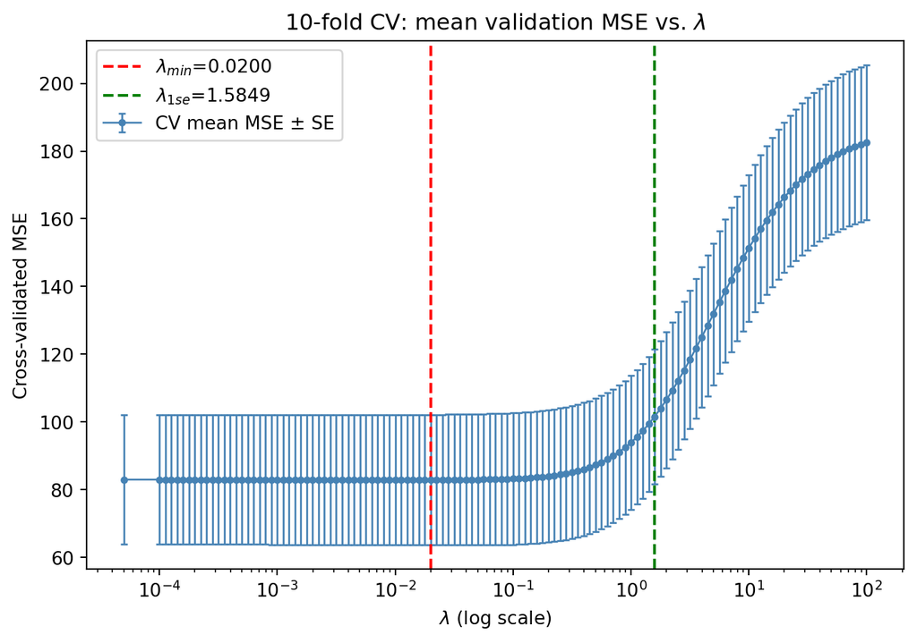

10-fold CV: mean validation MSE vs. lambda

```python
import matplotlib.pyplot as plt

lam_plot = lambdas.copy()
lam_plot[0] = 1e-4 / 2  # placeholder for lambda=0 so it can appear on a log axis

fig, ax = plt.subplots(figsize=(7, 5))
ax.errorbar(lam_plot, mean_mse, yerr=se_mse, fmt='o-', ms=3, lw=1,
            capsize=2, color='steelblue', label='CV mean MSE ± SE')
ax.axvline(lam_plot[idx_min], color='red', ls='--', label=f'$\\lambda_{{min}}$={lambda_min:.4f}')
ax.axvline(lambda_1se, color='green', ls='--', label=f'$\\lambda_{{1se}}$={lambda_1se:.4f}')
ax.set_xscale('log')
ax.set_xlabel('$\\lambda$ (log scale)')
ax.set_ylabel('Cross-validated MSE')
ax.set_title('10-fold CV: mean validation MSE vs. $\\lambda$')
ax.legend()
fig.tight_layout()
plt.show()
```

#### Part b

Means/scales are estimated **once**, from all 332 training observations, and held fixed.

**Show the workflow**

```python
Xs_all, mean_all, scale_all = standardize(Xtrain_full)
ybar_all = ytrain_full.mean()
ytilde_all = ytrain_full - ybar_all
n = n_train_full

U, S, Vt = np.linalg.svd(Xs_all, full_matrices=False)  # singular values of Xs_all

gcv_vals = np.zeros(n_lam)
train_mse_vals = np.zeros(n_lam)
df_eff_vals = np.zeros(n_lam)

for li, lam in enumerate(lambdas):
    b = ridge_fit(Xs_all, ytilde_all, lam, n)
    fitted = ybar_all + Xs_all @ b
    mse_train = np.mean((ytrain_full - fitted) ** 2)
    df_eff = 1 + np.sum(S**2 / (S**2 + n * lam))     # includes unpenalized intercept
    gcv = mse_train / (1 - df_eff / n) ** 2

    train_mse_vals[li] = mse_train
    df_eff_vals[li] = df_eff
    gcv_vals[li] = gcv

idx_gcv = np.argmin(gcv_vals)
lambda_gcv = lambdas[idx_gcv]
print(f"lambda_GCV = {lambda_gcv:.5f},  GCV = {gcv_vals[idx_gcv]:.4f},  df_eff = {df_eff_vals[idx_gcv]:.4f}")
```

```
lambda_GCV = 0.02818,  GCV = 83.5019,  df_eff = 6.6887
```

**Show the workflow**

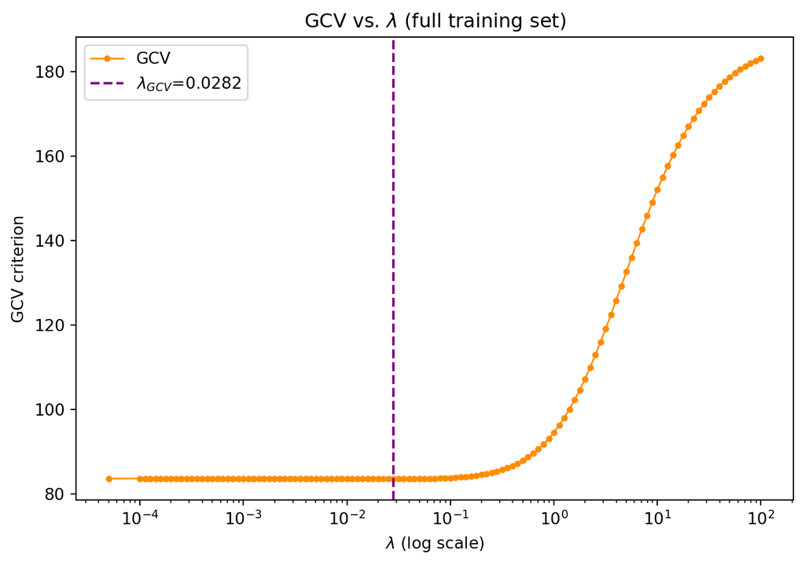

GCV criterion vs. lambda (full training set)

```python
fig2, ax2 = plt.subplots(figsize=(7, 5))
ax2.plot(lam_plot, gcv_vals, 'o-', ms=3, lw=1, color='darkorange', label='GCV')
ax2.axvline(lambda_gcv, color='purple', ls='--', label=f'$\\lambda_{{GCV}}$={lambda_gcv:.4f}')
ax2.set_xscale('log')
ax2.set_xlabel('$\\lambda$ (log scale)')
ax2.set_ylabel('GCV criterion')
ax2.set_title('GCV vs. $\\lambda$ (full training set)')
ax2.legend()
fig2.tight_layout()
plt.show()
```

**Result:** $\lambda_{\mathrm{GCV}} \approx 0.0282$, very close to $\lambda_{\min}$ from part (a) — as expected, since GCV approximates leave-one-out CV, and the GCV curve tracks the 10-fold CV curve closely across the whole grid.

#### Part c

All three $\lambda$ choices — $\lambda_{\min}$, $\lambda_{1\text{se}}$, $\lambda_{\mathrm{GCV}}$ — plus OLS ($\lambda=0$) are now fixed. Each is refit on **all 332 training observations**, and only now are the 82 test responses used.

**Show the workflow**

```python
chosen = {
    "OLS (lambda=0)": 0.0,
    "lambda_min":     lambda_min,
    "lambda_1se":     lambda_1se,
    "lambda_GCV":     lambda_gcv,
}

Xtest_s = apply_scale(Xtest, mean_all, scale_all)

rows = []
for name, lam in chosen.items():
    b = ridge_fit(Xs_all, ytilde_all, lam, n)
    fitted_train = ybar_all + Xs_all @ b
    mse_train = np.mean((ytrain_full - fitted_train) ** 2)

    fitted_test = ybar_all + Xtest_s @ b
    mse_test = np.mean((ytest - fitted_test) ** 2)

    df_eff = 1 + np.sum(S**2 / (S**2 + n * lam)) if lam > 0 else p + 1
    rows.append([name, lam, mse_train, mse_test, df_eff])

results_c = pd.DataFrame(rows, columns=["Model", "lambda", "Train MSE", "Test MSE", "df_eff"])
print(results_c.to_string(index=False, float_format=lambda x: f"{x:.4f}"))
```

```
         Model  lambda  Train MSE  Test MSE  df_eff
OLS (lambda=0)  0.0000    80.0939   66.3225  7.0000
    lambda_min  0.0200    80.1354   65.9996  6.7732
    lambda_1se  1.5849   100.3736   81.1998  3.0329
    lambda_GCV  0.0282    80.1713   65.9028  6.6887
```

| Model | $\lambda$ | Train MSE | Test MSE | df$_{\mathrm{eff}}$ |
| --- | --- | --- | --- | --- |
| OLS ($\lambda=0$) | 0 | 80.09 | 66.32 | 7.00 |
| $\lambda_{\min}$ | 0.0200 | 80.14 | 66.00 | 6.77 |
| $\lambda_{1\text{se}}$ | 1.5849 | 100.37 | 81.20 | 3.03 |
| $\lambda_{\mathrm{GCV}}$ | 0.0282 | 80.17 | 65.90 | 6.69 |

**Training vs. test MSE, and effective df.** Training MSE grows monotonically with $\lambda$ (80.09 → 80.14 → 80.17 → 100.37, following the increasing order $0<\lambda_{\min}<\lambda_{\mathrm{GCV}}<\lambda_{1\text{se}}$), because ridge always fits the training data slightly worse as the penalty grows. Effective degrees of freedom drop from the full $p+1=7$ at OLS down to about 6.7–6.8 at $\lambda_{\min}$/$\lambda_{\mathrm{GCV}}$ (very light shrinkage) and down to about 3.0 at $\lambda_{1\text{se}}$ (substantial shrinkage, roughly halving the effective model complexity).

**$\lambda_{\min}$ and $\lambda_{\mathrm{GCV}}$ nearly agree.** Both select very small penalties (0.020 and 0.028), essentially minor perturbations of OLS, and both slightly *improve* on OLS’s test MSE (66.00 and 65.90 vs. 66.32) — consistent with there being a small amount of collinearity/noise to damp out, but not much, since these six predictors (date, age, distance, stores, latitude, longitude) are not nearly as collinear as the engineered example in Question 2.

**$\lambda_{1\text{se}}$ chooses much more shrinkage** and, in this instance, ends up with a *worse* test MSE (81.20) than either OLS or the more lightly-penalized ridge fits. This is expected behavior for the one-SE rule: it deliberately trades a modest, statistically-indistinguishable increase in *estimated* CV error for a simpler, more parsimonious, lower-variance model — the CV curve shows that its mean MSE (101.60) is within one SE of the minimum, so the rule cannot statistically distinguish it from $\lambda_{\min}$ using the training-fold information alone. It is not guaranteed to win on any one particular test set draw.

**Why you must not select the model with the smallest observed test MSE.** In this table, $\lambda_{\mathrm{GCV}}$ happens to have the single lowest test MSE (65.90), even lower than $\lambda_{\min}$. But this is only true for this particular test split of 82 observations — the differences among OLS, $\lambda_{\min}$, and $\lambda_{\mathrm{GCV}}$ (66.32, 66.00, 65.90) are tiny relative to the sampling noise inherent in evaluating on 82 points (compare to the CV standard errors of $\approx19$ seen in part a). If we chose whichever model minimizes test MSE *after* looking at the test set, we would be tuning $\lambda$ using the test data itself, defeating its purpose as an honest, independent estimate of generalization error — the resulting selected model’s test MSE would then be optimistically biased (a form of data leakage / “peeking”), and it would no longer provide a valid estimate of how the chosen model performs on genuinely new data. All three $\lambda$ choices (and the decision rules that produced them) must be — and were — fixed using only the training folds and GCV before the test responses were ever examined; the test MSE table’s role is solely to *report and compare* the already-fixed choices, not to select among them.

## Reference

The real-estate data come from I-Cheng Yeh’s [Real Estate Valuation dataset](https://archive.ics.uci.edu/dataset/477/real%2Bestate%2Bvaluation%2Bda) in the UCI Machine Learning Repository. The distributed data retain the original observations and add only the course train-test and fold assignments.

## `explain-to-me` skill

```markdown
---
name: explain-to-me
description: Explain what a homework question is asking, without answering it. Use only when I explicitly ask to use explain-to-me on a specific question.
metadata:
  version: "1.0.0"
---

# explain-to-me

Invoke this skill only when I explicitly ask you to use `explain-to-me` on a named question (e.g. "use explain-to-me on Question 2").

For that question, in plain language:

1. State the **goal**: what quantity, relationship, or property the question wants me to find or demonstrate.
2. State the **required work**: which steps, derivations, simulations, or plots I need to produce to answer it — as a checklist, not worked-out.
3. Point me to the relevant section of the Week 3 lectures if one applies:
   - [Ridge Regression: Stability Through Shrinkage](https://teazrq.github.io/stat432rpy/topics/ridge-regression/ridge-regression.html)
   - [From a Penalized Objective to a Fitted Ridge Model](https://teazrq.github.io/stat432rpy/topics/ridge-regression/optimization-and-cross-validation.html)

Rules:

- Never compute, derive, simulate, or write code toward the actual answer — no numbers, formulas, or conclusions that the question asks me to produce.
- Never open or reference `solutions-03.qmd` or any solutions file.
- Keep the explanation short: a goal statement, a checklist, and (if relevant) one lecture link. Do not restate the entire question text back to me.
```